# Biostat 212a Homework 4

Due Mar. 5, 2024 @ 11:59PM

Author

Jiyin (Jenny) Zhang, UID: 606331859

Published

March 5, 2024

## 1 ISL Exercise 8.4.3 (10pts)

Consider the Gini index, classification error, and entropy in a simple classification setting with two classes. Create a single plot that displays each of these quantities as a function of $\hat p_{m1}$. The x-axis should display $\hat p_{m1}$, ranging from 0 to 1, and the $y$-axis should display the value of the Gini index, classification error, and entropy.

Hint: In a setting with two classes, $\hat p_{m1}$ = 1 − $\hat p_{m2}$. You could make this plot by hand, but it will be much easier to make in R.

**Answer:**

Create a data frame with $\hat p_{m1}$ ranging from 0 to 1, and calculate the Gini index, classification error, and entropy.

```r
library(ggplot2)
p <- seq(0, 1, 0.01)
df <- data.frame(
  p = p,
  gini = p * (1 - p) * 2,
  entropy = -(p * log(p) + (1 - p) * log(1 - p)),
  class_err = 1 - pmax(p, 1 - p)
)
print(df, width = 200)
```

```
       p   gini    entropy class_err
1   0.00 0.0000        NaN      0.00
2   0.01 0.0198 0.05600153      0.01
3   0.02 0.0392 0.09803911      0.02
4   0.03 0.0582 0.13474217      0.03
5   0.04 0.0768 0.16794415      0.04
6   0.05 0.0950 0.19851524      0.05
7   0.06 0.1128 0.22696752      0.06
8   0.07 0.1302 0.25363895      0.07
9   0.08 0.1472 0.27876937      0.08
10  0.09 0.1638 0.30253782      0.09
11  0.10 0.1800 0.32508297      0.10
12  0.11 0.1958 0.34651534      0.11
13  0.12 0.2112 0.36692499      0.12
14  0.13 0.2262 0.38638671      0.13
```

[output cut: 87 more lines]

Melt the data frame for ggplot:

```r
library(reshape2)
df_melted <- melt(df, id.vars = "p") |>
  print(width = 200)
```

```
       p  variable      value
1   0.00      gini 0.00000000
2   0.01      gini 0.01980000
3   0.02      gini 0.03920000
4   0.03      gini 0.05820000
5   0.04      gini 0.07680000
6   0.05      gini 0.09500000
7   0.06      gini 0.11280000
8   0.07      gini 0.13020000
9   0.08      gini 0.14720000
10  0.09      gini 0.16380000
11  0.10      gini 0.18000000
12  0.11      gini 0.19580000
13  0.12      gini 0.21120000
14  0.13      gini 0.22620000
```

[output cut: 289 more lines]

Then use `ggplot2` to plot the three quantities as a function of $\hat p_{m1}$.

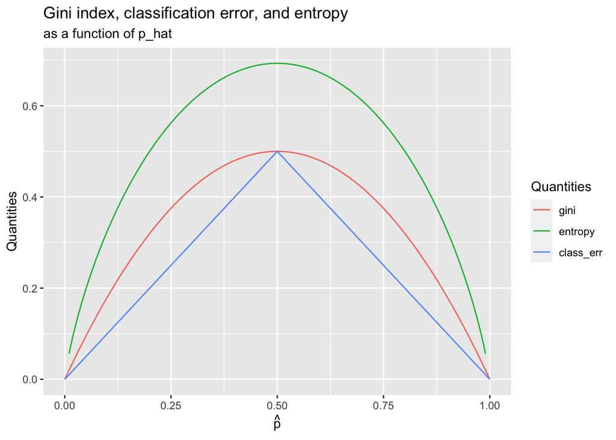

```r
# Plot using ggplot
ggplot(df_melted, aes(x = p, y = value, color = variable), na.rm = true) +
  geom_line() +
  labs(
    title = "Gini index, classification error, and entropy",
    subtitle = "as a function of p_hat",
    x = expression(hat(p)),
    y = "Quantities",
    color = "Quantities"
  )
```

## 2 ISL Exercise 8.4.4 (10pts)

This question relates to the plots in Figure 8.14.

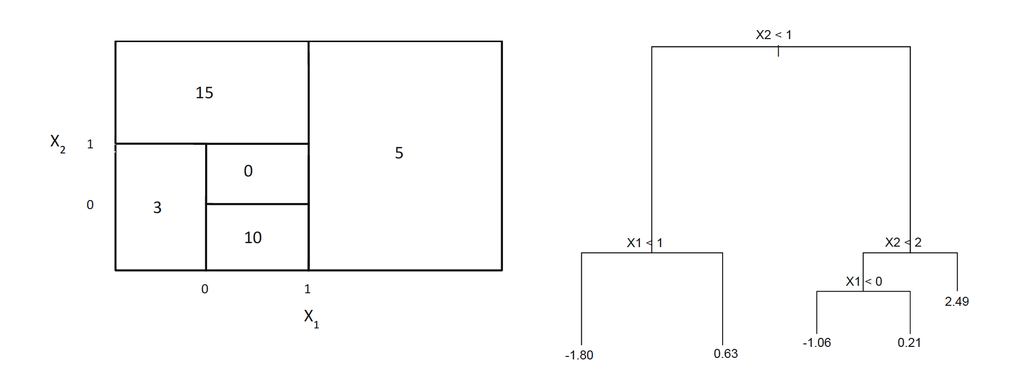

FIGURE 8.14. Left: A partition of the predictor space corresponding to Exercise 4a. Right: A tree corresponding to Exercise 4b.

**(a)** Sketch the tree corresponding to the partition of the predictor space illustrated in the left-hand panel of Figure 8.14. The numbers inside the boxes indicate the mean of $Y$ within each region.

**Answer:**

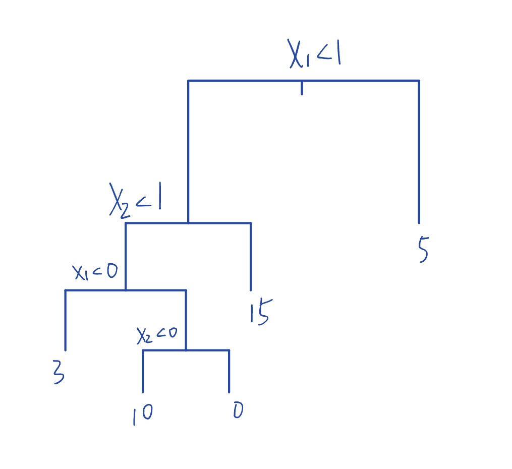

**(b)** Create a diagram similar to the left-hand panel of Figure 8.14, using the tree illustrated in the right-hand panel of the same figure. You should divide up the predictor space into the correct regions, and indicate the mean for each region.

**Answer:**

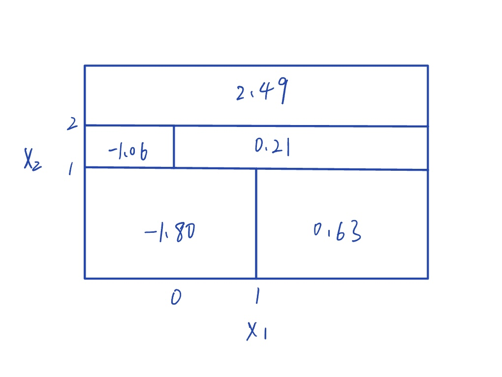

## 3 ISL Exercise 8.4.5 (10pts)

Suppose we produce ten bootstrapped samples from a data set containing red and green classes. We then apply a classification tree to each bootstrapped sample and, for a specific value of X, produce 10 estimates of $P$(Class is Red|X):

0.1, 0.15, 0.2, 0.2, 0.55, 0.6, 0.6, 0.65, 0.7, and 0.75.

There are two common ways to combine these results together into a single class prediction. One is the majority vote approach discussed in this chapter. The second approach is to classify based on the average probability. In this example, what is the final classification under each of these two approaches?

**Answer:**

Generate the data:

```r
estimates <- c(0.1, 0.15, 0.2, 0.2, 0.55, 0.6, 0.6, 0.65, 0.7, 0.75)
print(estimates)
```

```
 [1] 0.10 0.15 0.20 0.20 0.55 0.60 0.60 0.65 0.70 0.75
```

```r
num_estimates <- length(estimates)
cat('There are', num_estimates, 'estimates in total\n')
```

```
There are 10 estimates in total
```

Assuming a decision threshold probability of 0.5

```r
p_threshold <- 0.5
numRed <- sum(estimates >= p_threshold)
numGreen <- sum(estimates < p_threshold)
```

For the majority vote approach:

```r
cat('Using the majority vote approach:\n')
```

```
Using the majority vote approach:
```

```r
cat('The number of votes for class Red =', numRed, '\n')
```

```
The number of votes for class Red = 6
```

```r
cat('The number of votes for class Green =', numGreen, '\n')
```

```
The number of votes for class Green = 4
```

```r
if (numRed >= numGreen) {
  cat('The assigned class is Red\n')
} else {
  cat('The assigned class is Green\n')
}
```

```
The assigned class is Red
```

For the average probability approach:

```r
cat('Using the average vote approach:\n')
```

```
Using the average vote approach:
```

```r
mean_estimate <- mean(estimates)
cat('The mean estimate is', mean_estimate, '\n')
```

```
The mean estimate is 0.45
```

```r
if (mean_estimate >= p_threshold) {
  cat('The assigned class is Red\n')
} else {
  cat('The assigned class is Green\n')
}
```

```
The assigned class is Green
```

Histogram with threshold, mean, and median lines:

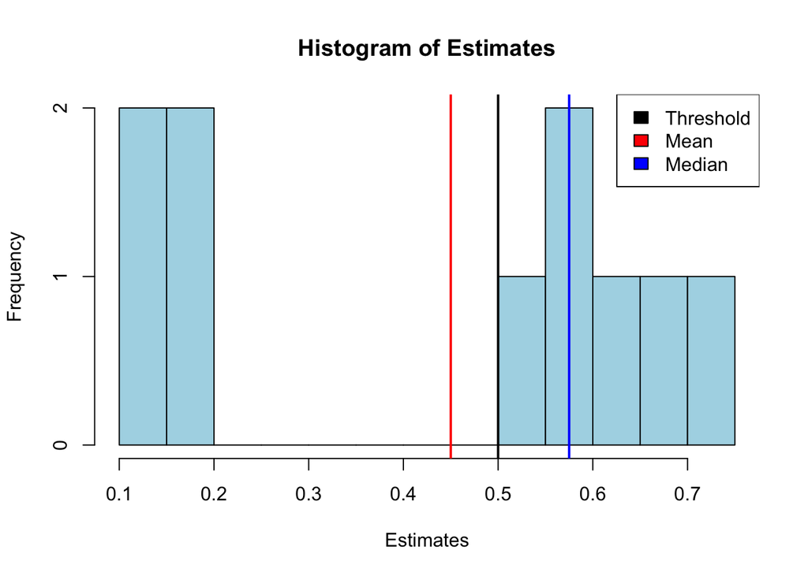

```r
hist(estimates, breaks = 10, main = "Histogram of Estimates", xlab = "Estimates", col = "lightblue")
abline(v = p_threshold, col = "black", lwd = 2)
abline(v = mean_estimate, col = "red", lwd = 2)
abline(v = median(estimates), col = "blue", lwd = 2)
legend("topright",
       legend = c("Threshold", "Mean", "Median"),
       fill = c("black", "red", "blue"))
```

## 4 ISL Lab 8.3. `Boston` data set (30pts)

Follow the machine learning workflow to train regression tree, random forest, and boosting methods for predicting `medv`. Evaluate out-of-sample performance on a test set.

**Answer:**

**Regression Tree**

**Boston dataset:**

```r
library(GGally)
library(gtsummary)
# install.packages("ranger")
library(ranger)
library(tidyverse)
library(tidymodels)
library(ISLR2)

# Numerical summaries
Boston %>% tbl_summary()
```

| **Characteristic** | **N = 506**<sup>1</sup> |
| --- | --- |
| crim | 0.3 (0.1, 3.7) |
| zn | 0 (0, 13) |
| indus | 9.7 (5.2, 18.1) |
| chas | 35 (6.9%) |
| nox | 0.54 (0.45, 0.62) |
| rm | 6.21 (5.89, 6.62) |
| age | 78 (45, 94) |
| dis | 3.21 (2.10, 5.19) |
| rad |  |
| 1 | 20 (4.0%) |
| 2 | 24 (4.7%) |
| 3 | 38 (7.5%) |
| 4 | 110 (22%) |
| 5 | 115 (23%) |
| 6 | 26 (5.1%) |
| 7 | 17 (3.4%) |
| 8 | 24 (4.7%) |
| 24 | 132 (26%) |
| tax | 330 (279, 666) |
| ptratio | 19.05 (17.40, 20.20) |
| lstat | 11 (7, 17) |
| medv | 21 (17, 25) |

<sup>1</sup> Median (IQR); n (%)

```r
Boston <- Boston %>% filter(!is.na(medv)) %>%
  print(width = 200)
```

```
        crim    zn indus chas    nox    rm   age     dis rad tax ptratio lstat medv
1    0.00632  18.0  2.31    0 0.5380 6.575  65.2  4.0900   1 296    15.3  4.98 24.0
2    0.02731   0.0  7.07    0 0.4690 6.421  78.9  4.9671   2 242    17.8  9.14 21.6
3    0.02729   0.0  7.07    0 0.4690 7.185  61.1  4.9671   2 242    17.8  4.03 34.7
4    0.03237   0.0  2.18    0 0.4580 6.998  45.8  6.0622   3 222    18.7  2.94 33.4
5    0.06905   0.0  2.18    0 0.4580 7.147  54.2  6.0622   3 222    18.7  5.33 36.2
6    0.02985   0.0  2.18    0 0.4580 6.430  58.7  6.0622   3 222    18.7  5.21 28.7
7    0.08829  12.5  7.87    0 0.5240 6.012  66.6  5.5605   5 311    15.2 12.43 22.9
8    0.14455  12.5  7.87    0 0.5240 6.172  96.1  5.9505   5 311    15.2 19.15 27.1
9    0.21124  12.5  7.87    0 0.5240 5.631 100.0  6.0821   5 311    15.2 29.93 16.5
10   0.17004  12.5  7.87    0 0.5240 6.004  85.9  6.5921   5 311    15.2 17.10 18.9
11   0.22489  12.5  7.87    0 0.5240 6.377  94.3  6.3467   5 311    15.2 20.45 15.0
12   0.11747  12.5  7.87    0 0.5240 6.009  82.9  6.2267   5 311    15.2 13.27 18.9
13   0.09378  12.5  7.87    0 0.5240 5.889  39.0  5.4509   5 311    15.2 15.71 21.7
14   0.62976   0.0  8.14    0 0.5380 5.949  61.8  4.7075   4 307    21.0  8.26 20.4
```

[output cut: 492 more lines]

**Initial split into test and non-test sets:**

```r
# For reproducibility
set.seed(203)

data_split <- initial_split(
  Boston,
  prop = 0.5
  )
data_split
```

```
<Training/Testing/Total>
<253/253/506>
```

```r
Boston_other <- training(data_split)
dim(Boston_other)
```

```
[1] 253  13
```

```r
Boston_test <- testing(data_split)
dim(Boston_test)
```

```
[1] 253  13
```

**Recipe:**

```r
tree_recipe <-
  recipe(
    medv ~ .,
    data = Boston_other
  ) %>%
  # # create traditional dummy variables (not necessary for random forest in R)
  # step_dummy(all_nominal()) %>%
  step_naomit(medv) %>%
  # zero-variance filter
  step_zv(all_numeric_predictors()) %>%
  # # center and scale numeric data (not necessary for random forest)
  # step_normalize(all_numeric_predictors()) %>%
  # estimate the means and standard deviations
  prep(training = Boston_other, retain = TRUE)
tree_recipe
```

**Model:**

```r
regtree_mod <- decision_tree(
  cost_complexity = tune(),
  tree_depth = tune(),
  min_n = 5,
  mode = "regression",
  engine = "rpart"
  )
```

**Workflow:**

```r
tree_wf <- workflow() %>%
  add_recipe(tree_recipe) %>%
  add_model(regtree_mod)
tree_wf
```

```
══ Workflow ════════════════════════════════════════════════════════════════════
Preprocessor: Recipe
Model: decision_tree()

── Preprocessor ────────────────────────────────────────────────────────────────
2 Recipe Steps

• step_naomit()
• step_zv()

── Model ───────────────────────────────────────────────────────────────────────
Decision Tree Model Specification (regression)

Main Arguments:
  cost_complexity = tune()
  tree_depth = tune()
  min_n = 5

Computational engine: rpart
```

**Tuning grid:**

```r
tree_grid <- grid_regular(cost_complexity(),
                          tree_depth(),
                          levels = c(100, 5))
```

**Cross-validation:**

```r
set.seed(203)

folds <- vfold_cv(Boston_other, v = 5)
folds
```

```
#  5-fold cross-validation
# A tibble: 5 × 2
  splits           id
  <list>           <chr>
1 <split [202/51]> Fold1
2 <split [202/51]> Fold2
3 <split [202/51]> Fold3
4 <split [203/50]> Fold4
5 <split [203/50]> Fold5
```

Fit cross-validation:

```r
tree_fit <- tree_wf %>%
  tune_grid(
    resamples = folds,
    grid = tree_grid,
    metrics = metric_set(rmse, rsq)
    )
tree_fit
```

```
# Tuning results
# 5-fold cross-validation
# A tibble: 5 × 4
  splits           id    .metrics             .notes
  <list>           <chr> <list>               <list>
1 <split [202/51]> Fold1 <tibble [1,000 × 6]> <tibble [0 × 3]>
2 <split [202/51]> Fold2 <tibble [1,000 × 6]> <tibble [0 × 3]>
3 <split [202/51]> Fold3 <tibble [1,000 × 6]> <tibble [0 × 3]>
4 <split [203/50]> Fold4 <tibble [1,000 × 6]> <tibble [0 × 3]>
5 <split [203/50]> Fold5 <tibble [1,000 × 6]> <tibble [0 × 3]>
```

Visualize CV results:

```
# A tibble: 1,000 × 8
   cost_complexity tree_depth .metric .estimator  mean     n std_err
             <dbl>      <int> <chr>   <chr>      <dbl> <int>   <dbl>
 1        1   e-10          1 rmse    standard   7.94      5  0.442
 2        1   e-10          1 rsq     standard   0.347     5  0.0740
 3        1.23e-10          1 rmse    standard   7.94      5  0.442
 4        1.23e-10          1 rsq     standard   0.347     5  0.0740
 5        1.52e-10          1 rmse    standard   7.94      5  0.442
 6        1.52e-10          1 rsq     standard   0.347     5  0.0740
 7        1.87e-10          1 rmse    standard   7.94      5  0.442
 8        1.87e-10          1 rsq     standard   0.347     5  0.0740
 9        2.31e-10          1 rmse    standard   7.94      5  0.442
10        2.31e-10          1 rsq     standard   0.347     5  0.0740
   .config
   <chr>
 1 Preprocessor1_Model001
 2 Preprocessor1_Model001
 3 Preprocessor1_Model002
 4 Preprocessor1_Model002
 5 Preprocessor1_Model003
 6 Preprocessor1_Model003
 7 Preprocessor1_Model004
 8 Preprocessor1_Model004
 9 Preprocessor1_Model005
10 Preprocessor1_Model005
# ℹ 990 more rows
```

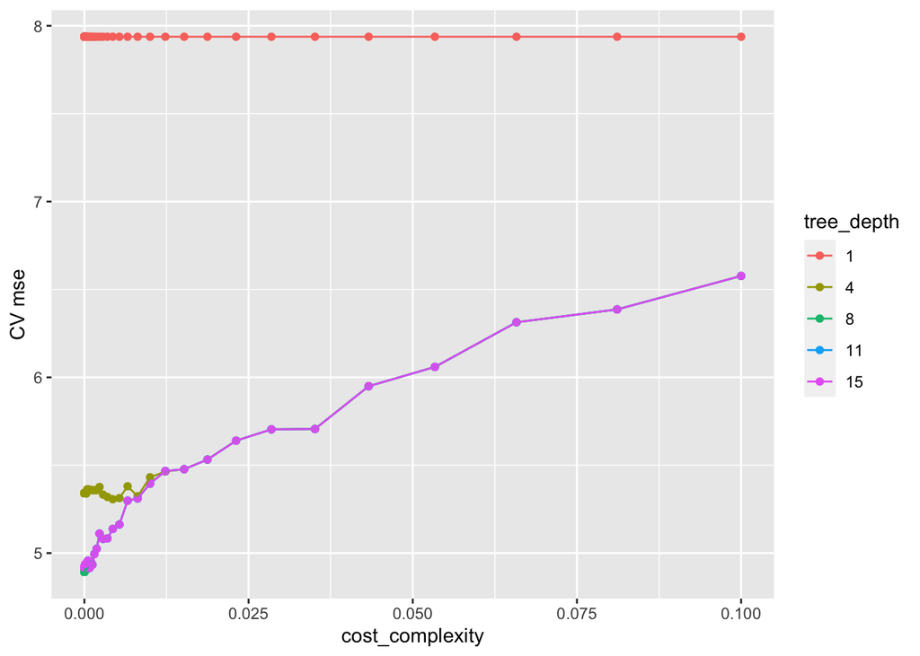

```r
tree_fit %>%
  collect_metrics() %>%
  print(width = Inf) %>%
  filter(.metric == "rmse") %>%
  mutate(tree_depth = as.factor(tree_depth)) %>%
  ggplot(mapping = aes(x = cost_complexity, y = mean, color = tree_depth)) +
  geom_point() +
  geom_line() +
  labs(x = "cost_complexity", y = "CV mse")
```

**Finalize our model:**

```r
tree_fit %>%
  show_best("rmse")
```

```
# A tibble: 5 × 8
  cost_complexity tree_depth .metric .estimator  mean     n std_err .config
            <dbl>      <int> <chr>   <chr>      <dbl> <int>   <dbl> <chr>
1        1   e-10          8 rmse    standard    4.89     5   0.717 Preprocesso…
2        1.23e-10          8 rmse    standard    4.89     5   0.717 Preprocesso…
3        1.52e-10          8 rmse    standard    4.89     5   0.717 Preprocesso…
4        1.87e-10          8 rmse    standard    4.89     5   0.717 Preprocesso…
5        2.31e-10          8 rmse    standard    4.89     5   0.717 Preprocesso…
```

Select the best model.

```r
best_tree <- tree_fit %>%
  select_best("rmse")
best_tree
```

```
# A tibble: 1 × 3
  cost_complexity tree_depth .config
            <dbl>      <int> <chr>
1    0.0000000001          8 Preprocessor1_Model201
```

```r
# Final workflow
final_wf <- tree_wf %>%
  finalize_workflow(best_tree)
final_wf
```

```
══ Workflow ════════════════════════════════════════════════════════════════════
Preprocessor: Recipe
Model: decision_tree()

── Preprocessor ────────────────────────────────────────────────────────────────
2 Recipe Steps

• step_naomit()
• step_zv()

── Model ───────────────────────────────────────────────────────────────────────
Decision Tree Model Specification (regression)

Main Arguments:
  cost_complexity = 1e-10
  tree_depth = 8
  min_n = 5

Computational engine: rpart
```

```r
# Fit the whole training set, then predict the test cases
final_fit <-
  final_wf %>%
  last_fit(data_split)
final_fit
```

```
# Resampling results
# Manual resampling
# A tibble: 1 × 6
  splits            id               .metrics .notes   .predictions .workflow
  <list>            <chr>            <list>   <list>   <list>       <list>
1 <split [253/253]> train/test split <tibble> <tibble> <tibble>     <workflow>
```

```r
# Test metrics
final_fit %>%
  collect_metrics()
```

```
# A tibble: 2 × 4
  .metric .estimator .estimate .config
  <chr>   <chr>          <dbl> <chr>
1 rmse    standard       5.07  Preprocessor1_Model1
2 rsq     standard       0.720 Preprocessor1_Model1
```

** Visualize the final model:**

```r
# install.packages("rpart.plot")
library(rpart.plot)
final_tree <- extract_workflow(final_fit)
final_tree
```

```
══ Workflow [trained] ══════════════════════════════════════════════════════════
Preprocessor: Recipe
Model: decision_tree()

── Preprocessor ────────────────────────────────────────────────────────────────
2 Recipe Steps

• step_naomit()
• step_zv()

── Model ───────────────────────────────────────────────────────────────────────
n= 253

node), split, n, deviance, yval
      * denotes terminal node

  1) root 253 2.337441e+04 22.451380
    2) rm< 6.754 208 8.878604e+03 19.383650
      4) lstat>=14.75 83 1.457504e+03 14.308430
        8) crim>=5.22624 42 4.284764e+02 11.764290
         16) lstat>=20.2 22 2.211150e+02 10.150000
           32) nox>=0.6425 19 8.364000e+01  9.200000
             64) lstat>=24.235 9 1.810889e+01  7.611111
              128) dis< 1.5094 2 8.450000e-01  5.650000 *
              129) dis>=1.5094 7 7.374286e+00  8.171429
                258) crim>=16.97245 3 8.000000e-02  7.200000 *
                259) crim< 16.97245 4 2.340000e+00  8.900000 *
             65) lstat< 24.235 10 2.236100e+01 10.630000
              130) nox< 0.6965 5 9.652000e+00  9.760000
                260) age>=99.55 2 4.500000e+00  8.700000 *
                261) age< 99.55 3 1.406667e+00 10.466670 *
              131) nox>=0.6965 5 5.140000e+00 11.500000
                262) crim>=11.98135 2 4.500000e-02 10.650000 *
                263) crim< 11.98135 3 2.686667e+00 12.066670 *
           33) nox< 0.6425 3 1.172667e+01 16.166670 *
         17) lstat< 20.2 20 8.696800e+01 13.540000
           34) age< 99.45 17 6.234471e+01 13.082350
             68) rm< 5.817 2 5.120000e+00 10.100000 *
             69) rm>=5.817 15 3.706400e+01 13.480000
              138) crim>=13.6366 2 2.205000e+00 10.650000 *
```

[output cut: 9 more lines]

```
              146) ptratio>=20.6 4 4.200000e-01 13.200000 *
              147) ptratio< 20.6 8 4.035500e+01 16.325000
                294) nox>=0.6485 4 1.338750e+01 15.125000 *
                295) nox< 0.6485 4 1.544750e+01 17.525000 *
           37) lstat< 18.845 23 1.051574e+02 17.347830
             74) crim>=0.614845 9 3.426222e+01 15.755560
              148) crim< 3.9419 6 1.030000e+01 14.800000
                296) lstat>=15.58 4 4.730000e+00 14.150000 *
                297) lstat< 15.58 2 5.000000e-01 16.100000 *
              149) crim>=3.9419 3 7.526667e+00 17.666670 *
             75) crim< 0.614845 14 3.340857e+01 18.371430
              150) nox>=0.5455 8 8.738750e+00 17.362500

...
and 70 more lines.
```

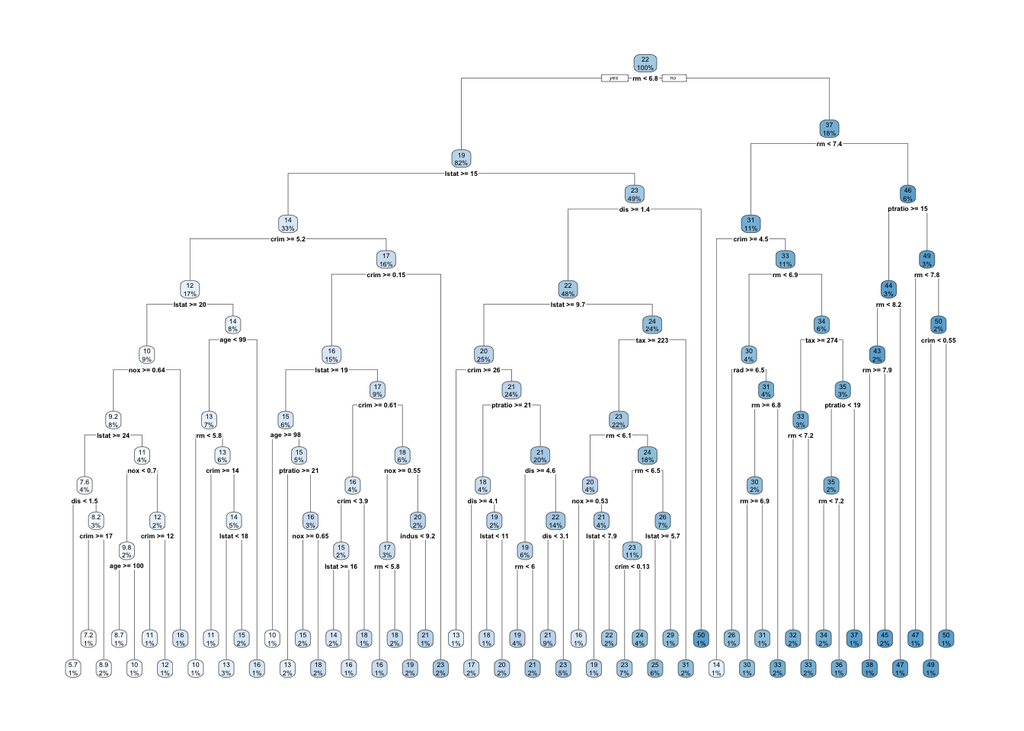

```r
final_tree %>%
  extract_fit_engine() %>%
  rpart.plot(roundint = FALSE)
```

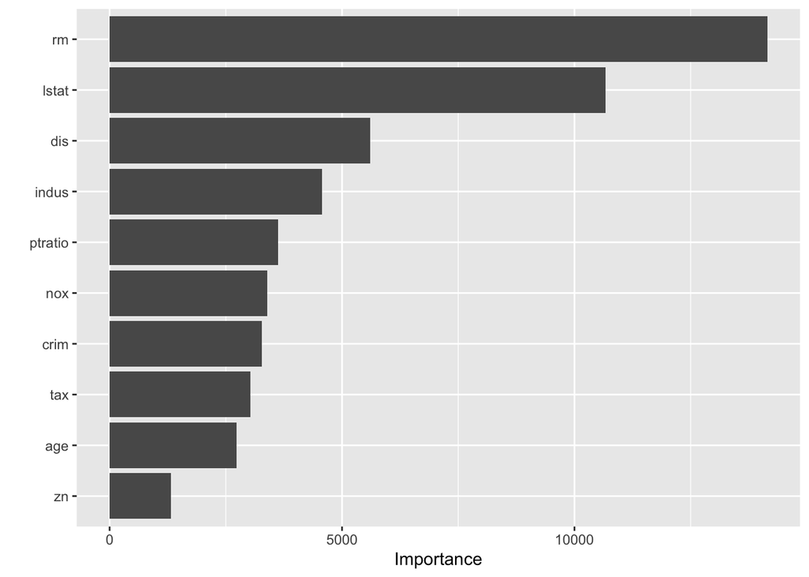

```r
# install.packages("vip")
library(vip)

final_tree %>%
  extract_fit_parsnip() %>%
  vip()
```

**random forest**

**Model:**

**Recipe**

```r
rf_recipe <-
  recipe(
    medv ~ .,
    data = Boston_other
  ) %>%
  # # create traditional dummy variables (not necessary for random forest in R)
  # step_dummy(all_nominal()) %>%
  step_naomit(medv) %>%
  # zero-variance filter
  step_zv(all_numeric_predictors()) %>%
  # # center and scale numeric data (not necessary for random forest)
  # step_normalize(all_numeric_predictors()) %>%
  # estimate the means and standard deviations
  prep(training = Boston_other, retain = TRUE)
rf_recipe
```

```r
rf_mod <-
  rand_forest(
    mode = "regression",
    # Number of predictors randomly sampled in each split
    mtry = tune(),
    # Number of trees in ensemble
    trees = tune()
  ) %>%
  set_engine("ranger")
rf_mod
```

```
Random Forest Model Specification (regression)

Main Arguments:
  mtry = tune()
  trees = tune()

Computational engine: ranger
```

**Workflow:**

```r
rf_wf <- workflow() %>%
  add_recipe(rf_recipe) %>%
  add_model(rf_mod)
rf_wf
```

```
══ Workflow ════════════════════════════════════════════════════════════════════
Preprocessor: Recipe
Model: rand_forest()

── Preprocessor ────────────────────────────────────────────────────────────────
2 Recipe Steps

• step_naomit()
• step_zv()

── Model ───────────────────────────────────────────────────────────────────────
Random Forest Model Specification (regression)

Main Arguments:
  mtry = tune()
  trees = tune()

Computational engine: ranger
```

**Tuning grid:**

```r
param_grid <- grid_regular(
  trees(range = c(100L, 300L)),
  mtry(range = c(1L, 5L)),
  levels = c(3, 5)
  )
param_grid
```

```
# A tibble: 15 × 2
   trees  mtry
   <int> <int>
 1   100     1
 2   200     1
 3   300     1
 4   100     2
 5   200     2
 6   300     2
 7   100     3
 8   200     3
 9   300     3
10   100     4
11   200     4
12   300     4
13   100     5
14   200     5
15   300     5
```

**Cross-validation:**

```r
set.seed(203)

folds <- vfold_cv(Boston_other, v = 5)
folds
```

```
#  5-fold cross-validation
# A tibble: 5 × 2
  splits           id
  <list>           <chr>
1 <split [202/51]> Fold1
2 <split [202/51]> Fold2
3 <split [202/51]> Fold3
4 <split [203/50]> Fold4
5 <split [203/50]> Fold5
```

Fit cross-validation:

```r
rf_fit <- rf_wf %>%
  tune_grid(
    resamples = folds,
    grid = param_grid,
    metrics = metric_set(rmse, rsq)
    )
rf_fit
```

```
# Tuning results
# 5-fold cross-validation
# A tibble: 5 × 4
  splits           id    .metrics          .notes
  <list>           <chr> <list>            <list>
1 <split [202/51]> Fold1 <tibble [30 × 6]> <tibble [0 × 3]>
2 <split [202/51]> Fold2 <tibble [30 × 6]> <tibble [0 × 3]>
3 <split [202/51]> Fold3 <tibble [30 × 6]> <tibble [0 × 3]>
4 <split [203/50]> Fold4 <tibble [30 × 6]> <tibble [0 × 3]>
5 <split [203/50]> Fold5 <tibble [30 × 6]> <tibble [0 × 3]>
```

Visualize CV results:

```
# A tibble: 30 × 8
    mtry trees .metric .estimator  mean     n std_err .config
   <int> <int> <chr>   <chr>      <dbl> <int>   <dbl> <chr>
 1     1   100 rmse    standard   5.16      5  0.424  Preprocessor1_Model01
 2     1   100 rsq     standard   0.739     5  0.0827 Preprocessor1_Model01
 3     1   200 rmse    standard   5.07      5  0.434  Preprocessor1_Model02
 4     1   200 rsq     standard   0.745     5  0.0842 Preprocessor1_Model02
 5     1   300 rmse    standard   5.14      5  0.470  Preprocessor1_Model03
 6     1   300 rsq     standard   0.739     5  0.0915 Preprocessor1_Model03
 7     2   100 rmse    standard   4.27      5  0.552  Preprocessor1_Model04
 8     2   100 rsq     standard   0.797     5  0.0811 Preprocessor1_Model04
 9     2   200 rmse    standard   4.41      5  0.559  Preprocessor1_Model05
10     2   200 rsq     standard   0.784     5  0.0858 Preprocessor1_Model05
# ℹ 20 more rows
```

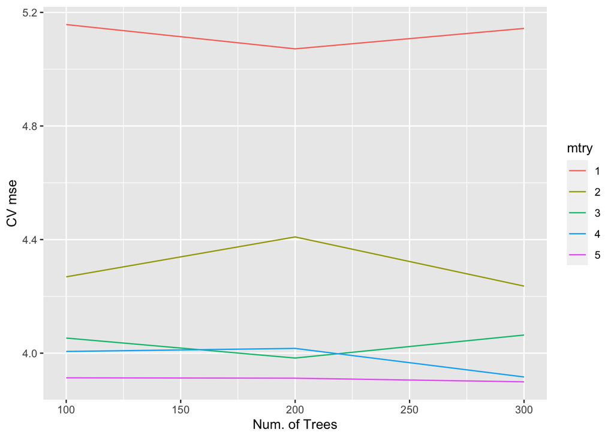

```r
rf_fit %>%
  collect_metrics() %>%
  print(width = Inf) %>%
  filter(.metric == "rmse") %>%
  mutate(mtry = as.factor(mtry)) %>%
  ggplot(mapping = aes(x = trees, y = mean, color = mtry)) +
  # geom_point() +
  geom_line() +
  labs(x = "Num. of Trees", y = "CV mse")
```

Show the top 5 models:

```r
rf_fit %>%
  show_best("rmse")
```

```
# A tibble: 5 × 8
   mtry trees .metric .estimator  mean     n std_err .config
  <int> <int> <chr>   <chr>      <dbl> <int>   <dbl> <chr>
1     5   300 rmse    standard    3.90     5   0.598 Preprocessor1_Model15
2     5   200 rmse    standard    3.91     5   0.598 Preprocessor1_Model14
3     5   100 rmse    standard    3.91     5   0.691 Preprocessor1_Model13
4     4   300 rmse    standard    3.92     5   0.629 Preprocessor1_Model12
5     3   200 rmse    standard    3.98     5   0.596 Preprocessor1_Model08
```

Select the best model:

```r
best_rf <- rf_fit %>%
  select_best("rmse")
best_rf
```

```
# A tibble: 1 × 3
   mtry trees .config
  <int> <int> <chr>
1     5   300 Preprocessor1_Model15
```

**Finalize our model:**

```r
# Final workflow
final_wf <- rf_wf %>%
  finalize_workflow(best_rf)
final_wf
```

```
══ Workflow ════════════════════════════════════════════════════════════════════
Preprocessor: Recipe
Model: rand_forest()

── Preprocessor ────────────────────────────────────────────────────────────────
2 Recipe Steps

• step_naomit()
• step_zv()

── Model ───────────────────────────────────────────────────────────────────────
Random Forest Model Specification (regression)

Main Arguments:
  mtry = 5
  trees = 300

Computational engine: ranger
```

```r
# Fit the whole training set, then predict the test cases
final_fit <-
  final_wf %>%
  last_fit(data_split)
final_fit
```

```
# Resampling results
# Manual resampling
# A tibble: 1 × 6
  splits            id               .metrics .notes   .predictions .workflow
  <list>            <chr>            <list>   <list>   <list>       <list>
1 <split [253/253]> train/test split <tibble> <tibble> <tibble>     <workflow>
```

```r
# Test metrics
final_fit %>%
  collect_metrics()
```

```
# A tibble: 2 × 4
  .metric .estimator .estimate .config
  <chr>   <chr>          <dbl> <chr>
1 rmse    standard       3.13  Preprocessor1_Model1
2 rsq     standard       0.873 Preprocessor1_Model1
```

**Boosting methods**

**Recipe:**

```r
gb_recipe <-
  recipe(
    medv ~ .,
    data = Boston_other
  ) %>%
  # # create traditional dummy variables (not necessary for random forest in R)
  # step_dummy(all_nominal()) %>%
  step_naomit(medv) %>%
  # zero-variance filter
  step_zv(all_numeric_predictors()) %>%
  # # center and scale numeric data (not necessary for random forest)
  # step_normalize(all_numeric_predictors()) %>%
  # estimate the means and standard deviations
  prep(training = Boston_other, retain = TRUE)
gb_recipe
```

**Model:**

```r
gb_mod <-
  boost_tree(
    mode = "regression",
    trees = 1000,
    tree_depth = tune(),
    learn_rate = tune()
  ) %>%
  set_engine("xgboost")
gb_mod
```

```
Boosted Tree Model Specification (regression)

Main Arguments:
  trees = 1000
  tree_depth = tune()
  learn_rate = tune()

Computational engine: xgboost
```

**Workflow:**

```r
gb_wf <- workflow() %>%
  add_recipe(gb_recipe) %>%
  add_model(gb_mod)
gb_wf
```

```
══ Workflow ════════════════════════════════════════════════════════════════════
Preprocessor: Recipe
Model: boost_tree()

── Preprocessor ────────────────────────────────────────────────────────────────
2 Recipe Steps

• step_naomit()
• step_zv()

── Model ───────────────────────────────────────────────────────────────────────
Boosted Tree Model Specification (regression)

Main Arguments:
  trees = 1000
  tree_depth = tune()
  learn_rate = tune()

Computational engine: xgboost
```

**Tuning grid:**

```r
param_grid <- grid_regular(
  tree_depth(range = c(1L, 4L)),
  learn_rate(range = c(-3, -0.5), trans = log10_trans()),
  levels = c(4, 10)
  )
param_grid
```

```
# A tibble: 40 × 2
   tree_depth learn_rate
        <int>      <dbl>
 1          1    0.001
 2          2    0.001
 3          3    0.001
 4          4    0.001
 5          1    0.00190
 6          2    0.00190
 7          3    0.00190
 8          4    0.00190
 9          1    0.00359
10          2    0.00359
# ℹ 30 more rows
```

**Cross-validation:**

```r
set.seed(203)

folds <- vfold_cv(Boston_other, v = 5)
folds
```

```
#  5-fold cross-validation
# A tibble: 5 × 2
  splits           id
  <list>           <chr>
1 <split [202/51]> Fold1
2 <split [202/51]> Fold2
3 <split [202/51]> Fold3
4 <split [203/50]> Fold4
5 <split [203/50]> Fold5
```

Fit cross-validation:

```r
# install.packages("xgboost")
library(xgboost)
gb_fit <- gb_wf %>%
  tune_grid(
    resamples = folds,
    grid = param_grid,
    metrics = metric_set(rmse, rsq)
    )
gb_fit
```

```
# Tuning results
# 5-fold cross-validation
# A tibble: 5 × 4
  splits           id    .metrics          .notes
  <list>           <chr> <list>            <list>
1 <split [202/51]> Fold1 <tibble [80 × 6]> <tibble [0 × 3]>
2 <split [202/51]> Fold2 <tibble [80 × 6]> <tibble [0 × 3]>
3 <split [202/51]> Fold3 <tibble [80 × 6]> <tibble [0 × 3]>
4 <split [203/50]> Fold4 <tibble [80 × 6]> <tibble [0 × 3]>
5 <split [203/50]> Fold5 <tibble [80 × 6]> <tibble [0 × 3]>
```

Visualize CV results:

```
# A tibble: 80 × 8
   tree_depth learn_rate .metric .estimator   mean     n std_err
        <int>      <dbl> <chr>   <chr>       <dbl> <int>   <dbl>
 1          1    0.001   rmse    standard   10.7       5  0.392
 2          1    0.001   rsq     standard    0.714     5  0.0598
 3          2    0.001   rmse    standard   10.2       5  0.445
 4          2    0.001   rsq     standard    0.750     5  0.0861
 5          3    0.001   rmse    standard   10.2       5  0.450
 6          3    0.001   rsq     standard    0.762     5  0.0838
 7          4    0.001   rmse    standard   10.1       5  0.439
 8          4    0.001   rsq     standard    0.766     5  0.0840
 9          1    0.00190 rmse    standard    6.64      5  0.400
10          1    0.00190 rsq     standard    0.752     5  0.0732
   .config
   <chr>
 1 Preprocessor1_Model01
 2 Preprocessor1_Model01
 3 Preprocessor1_Model02
 4 Preprocessor1_Model02
 5 Preprocessor1_Model03
 6 Preprocessor1_Model03
 7 Preprocessor1_Model04
 8 Preprocessor1_Model04
 9 Preprocessor1_Model05
10 Preprocessor1_Model05
# ℹ 70 more rows
```

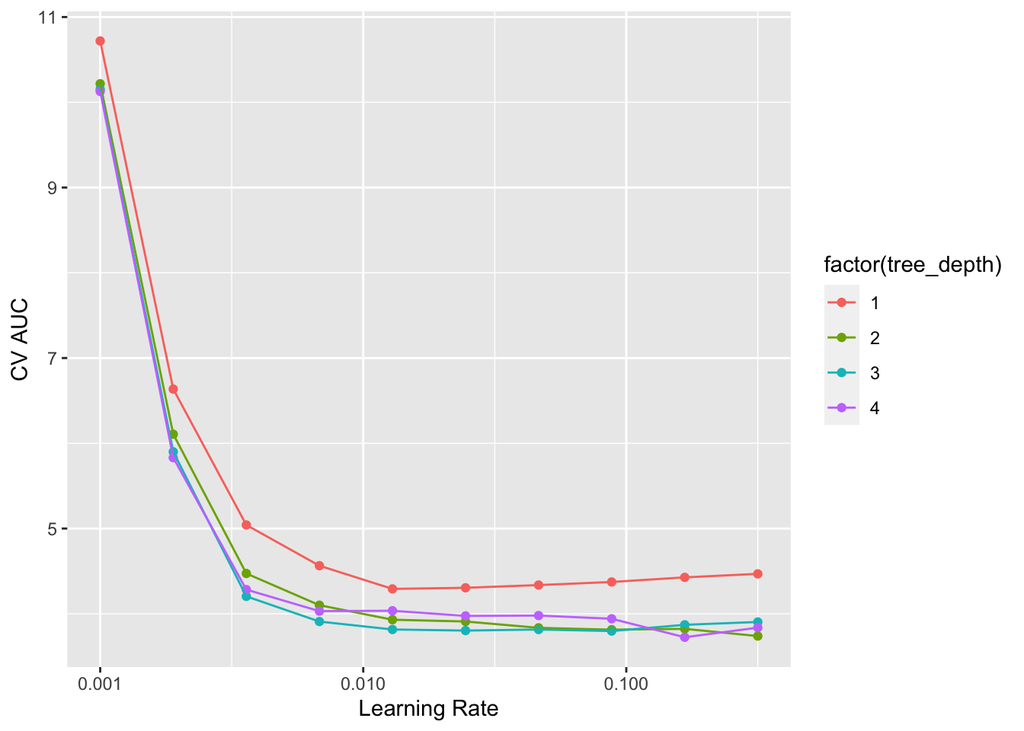

```r
gb_fit %>%
  collect_metrics() %>%
  print(width = Inf) %>%
  filter(.metric == "rmse") %>%
  ggplot(mapping = aes(x = learn_rate, y = mean, color = factor(tree_depth))) +
  geom_point() +
  geom_line() +
  labs(x = "Learning Rate", y = "CV AUC") +
  scale_x_log10()
```

Show the top 5 models.

```r
gb_fit %>%
  show_best("rmse")
```

```
# A tibble: 5 × 8
  tree_depth learn_rate .metric .estimator  mean     n std_err .config
       <int>      <dbl> <chr>   <chr>      <dbl> <int>   <dbl> <chr>
1          4     0.167  rmse    standard    3.72     5   0.298 Preprocessor1_Mo…
2          2     0.316  rmse    standard    3.74     5   0.260 Preprocessor1_Mo…
3          3     0.0880 rmse    standard    3.80     5   0.378 Preprocessor1_Mo…
4          3     0.0245 rmse    standard    3.80     5   0.393 Preprocessor1_Mo…
5          2     0.0880 rmse    standard    3.81     5   0.399 Preprocessor1_Mo…
```

Select the best model.

```r
best_gb <- gb_fit %>%
  select_best("rmse")
best_gb
```

```
# A tibble: 1 × 3
  tree_depth learn_rate .config
       <int>      <dbl> <chr>
1          4      0.167 Preprocessor1_Model36
```

**Finalize our model:**

```r
# Final workflow
final_wf <- gb_wf %>%
  finalize_workflow(best_gb)
final_wf
```

```
══ Workflow ════════════════════════════════════════════════════════════════════
Preprocessor: Recipe
Model: boost_tree()

── Preprocessor ────────────────────────────────────────────────────────────────
2 Recipe Steps

• step_naomit()
• step_zv()

── Model ───────────────────────────────────────────────────────────────────────
Boosted Tree Model Specification (regression)

Main Arguments:
  trees = 1000
  tree_depth = 4
  learn_rate = 0.166810053720006

Computational engine: xgboost
```

```r
# Fit the whole training set, then predict the test cases
final_fit <-
  final_wf %>%
  last_fit(data_split)
final_fit
```

```
# Resampling results
# Manual resampling
# A tibble: 1 × 6
  splits            id               .metrics .notes   .predictions .workflow
  <list>            <chr>            <list>   <list>   <list>       <list>
1 <split [253/253]> train/test split <tibble> <tibble> <tibble>     <workflow>
```

```r
# Test metrics
final_fit %>%
  collect_metrics()
```

```
# A tibble: 2 × 4
  .metric .estimator .estimate .config
  <chr>   <chr>          <dbl> <chr>
1 rmse    standard       3.82  Preprocessor1_Model1
2 rsq     standard       0.821 Preprocessor1_Model1
```

**Visualize the final model:**

```r
#library(rpart.plot)
final_tree <- extract_workflow(final_fit)
final_tree
```

```
══ Workflow [trained] ══════════════════════════════════════════════════════════
Preprocessor: Recipe
Model: boost_tree()

── Preprocessor ────────────────────────────────────────────────────────────────
2 Recipe Steps

• step_naomit()
• step_zv()

── Model ───────────────────────────────────────────────────────────────────────
##### xgb.Booster
raw: 1.1 Mb
call:
  xgboost::xgb.train(params = list(eta = 0.166810053720006, max_depth = 4L,
    gamma = 0, colsample_bytree = 1, colsample_bynode = 1, min_child_weight = 1,
    subsample = 1), data = x$data, nrounds = 1000, watchlist = x$watchlist,
    verbose = 0, nthread = 1, objective = "reg:squarederror")
params (as set within xgb.train):
  eta = "0.166810053720006", max_depth = "4", gamma = "0", colsample_bytree = "1", colsample_bynode = "1", min_child_weight = "1", subsample = "1", nthread = "1", objective = "reg:squarederror", validate_parameters = "TRUE"
xgb.attributes:
  niter
callbacks:
  cb.evaluation.log()
# of features: 12
niter: 1000
nfeatures : 12
evaluation_log:
    iter training_rmse
       1  20.219223169
       2  17.075695605
---
     999   0.001545644
    1000   0.001545644
```

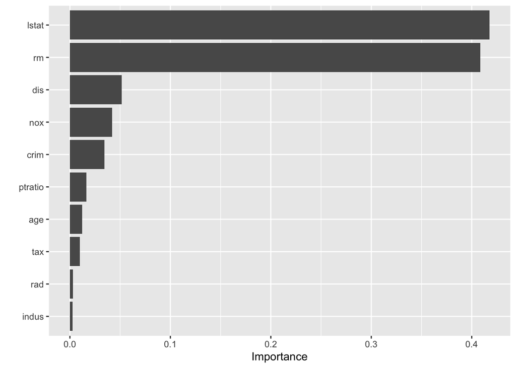

```r
library(vip)

final_tree %>%
  extract_fit_parsnip() %>%
  vip()
```

## 5 ISL Lab 8.3 `Carseats` data set (30pts)

Follow the machine learning workflow to train classification tree, random forest, and boosting methods for classifying `Sales <= 8` versus `Sales > 8`. Evaluate out-of-sample performance on a test set.

**Answer:**

**classification tree:**

**Carseats dataset:**

```r
# Numerical summaries
Carseats %>% tbl_summary()
```

| **Characteristic** | **N = 400**<sup>1</sup> |
| --- | --- |
| Sales | 7.49 (5.39, 9.32) |
| CompPrice | 125 (115, 135) |
| Income | 69 (43, 91) |
| Advertising | 5.0 (0.0, 12.0) |
| Population | 272 (139, 399) |
| Price | 117 (100, 131) |
| ShelveLoc |  |
| Bad | 96 (24%) |
| Good | 85 (21%) |
| Medium | 219 (55%) |
| Age | 55 (40, 66) |
| Education |  |
| 10 | 48 (12%) |
| 11 | 48 (12%) |
| 12 | 49 (12%) |
| 13 | 43 (11%) |
| 14 | 40 (10%) |
| 15 | 36 (9.0%) |
| 16 | 47 (12%) |
| 17 | 49 (12%) |
| 18 | 40 (10%) |
| Urban | 282 (71%) |
| US | 258 (65%) |

<sup>1</sup> Median (IQR); n (%)

```r
Carseats <- Carseats %>% filter(!is.na(Sales)) %>%
  mutate(Sales = ifelse(Sales <= 8, "Low", "High")) %>%
  print(width = 200)
```

```
    Sales CompPrice Income Advertising Population Price ShelveLoc Age Education Urban  US
1    High       138     73          11        276   120       Bad  42        17   Yes Yes
2    High       111     48          16        260    83      Good  65        10   Yes Yes
3    High       113     35          10        269    80    Medium  59        12   Yes Yes
4     Low       117    100           4        466    97    Medium  55        14   Yes Yes
5     Low       141     64           3        340   128       Bad  38        13   Yes  No
6    High       124    113          13        501    72       Bad  78        16    No Yes
7     Low       115    105           0         45   108    Medium  71        15   Yes  No
8    High       136     81          15        425   120      Good  67        10   Yes Yes
9     Low       132    110           0        108   124    Medium  76        10    No  No
10    Low       132    113           0        131   124    Medium  76        17    No Yes
11   High       121     78           9        150   100       Bad  26        10    No Yes
12   High       117     94           4        503    94      Good  50        13   Yes Yes
13    Low       122     35           2        393   136    Medium  62        18   Yes  No
14   High       115     28          11         29    86      Good  53        18   Yes Yes
```

[output cut: 386 more lines]

**Initial split into test and non-test sets:**

```r
# For reproducibility
set.seed(212)

data_split <- initial_split(
  Carseats,
  prop = 0.5,
  strata = Sales
  )
data_split
```

```
<Training/Testing/Total>
<200/200/400>
```

```r
Carseats_other <- training(data_split)
dim(Carseats_other)
```

```
[1] 200  11
```

```r
Carseats_test <- testing(data_split)
dim(Carseats_test)
```

```
[1] 200  11
```

**Recipe:**

```r
tree_recipe <-
  recipe(
    Sales ~ .,
    data = Carseats_other
  ) %>%
  step_naomit(all_predictors()) %>%
  # # create traditional dummy variables (not necessary for random forest in R)
  step_dummy(all_nominal_predictors()) %>%
  # zero-variance filter
  step_zv(all_numeric_predictors()) %>%
  # # center and scale numeric data (not necessary for random forest)
  step_normalize(all_numeric_predictors()) %>%
  # estimate the means and standard deviations
  prep(training = Carseats_other, retain = TRUE)
tree_recipe
```

**Model:**

```r
classtree_mod <- decision_tree(
  cost_complexity = tune(),
  tree_depth = tune(),
  min_n = 5,
  mode = "classification",
  engine = "rpart"
  )
```

**Workflow:**

```r
tree_wf <- workflow() %>%
  add_recipe(tree_recipe) %>%
  add_model(classtree_mod)
tree_wf
```

```
══ Workflow ════════════════════════════════════════════════════════════════════
Preprocessor: Recipe
Model: decision_tree()

── Preprocessor ────────────────────────────────────────────────────────────────
4 Recipe Steps

• step_naomit()
• step_dummy()
• step_zv()
• step_normalize()

── Model ───────────────────────────────────────────────────────────────────────
Decision Tree Model Specification (classification)

Main Arguments:
  cost_complexity = tune()
  tree_depth = tune()
  min_n = 5

Computational engine: rpart
```

**Tuning grid:**

```r
tree_grid <- grid_regular(cost_complexity(),
                          tree_depth(),
                          levels = c(100,5))
```

**Cross-validation:**

```r
set.seed(212)

folds <- vfold_cv(Carseats_other, v = 5)
folds
```

```
#  5-fold cross-validation
# A tibble: 5 × 2
  splits           id
  <list>           <chr>
1 <split [160/40]> Fold1
2 <split [160/40]> Fold2
3 <split [160/40]> Fold3
4 <split [160/40]> Fold4
5 <split [160/40]> Fold5
```

Fit cross-validation:

```r
tree_fit <- tree_wf %>%
  tune_grid(
    resamples = folds,
    grid = tree_grid,
    metrics = metric_set(accuracy, roc_auc)
    )
tree_fit
```

```
# Tuning results
# 5-fold cross-validation
# A tibble: 5 × 4
  splits           id    .metrics             .notes
  <list>           <chr> <list>               <list>
1 <split [160/40]> Fold1 <tibble [1,000 × 6]> <tibble [0 × 3]>
2 <split [160/40]> Fold2 <tibble [1,000 × 6]> <tibble [0 × 3]>
3 <split [160/40]> Fold3 <tibble [1,000 × 6]> <tibble [0 × 3]>
4 <split [160/40]> Fold4 <tibble [1,000 × 6]> <tibble [0 × 3]>
5 <split [160/40]> Fold5 <tibble [1,000 × 6]> <tibble [0 × 3]>
```

Visualize CV results:

```
# A tibble: 1,000 × 8
   cost_complexity tree_depth .metric  .estimator  mean     n std_err
             <dbl>      <int> <chr>    <chr>      <dbl> <int>   <dbl>
 1        1   e-10          1 accuracy binary     0.685     5  0.0232
 2        1   e-10          1 roc_auc  binary     0.629     5  0.0298
 3        1.23e-10          1 accuracy binary     0.685     5  0.0232
 4        1.23e-10          1 roc_auc  binary     0.629     5  0.0298
 5        1.52e-10          1 accuracy binary     0.685     5  0.0232
 6        1.52e-10          1 roc_auc  binary     0.629     5  0.0298
 7        1.87e-10          1 accuracy binary     0.685     5  0.0232
 8        1.87e-10          1 roc_auc  binary     0.629     5  0.0298
 9        2.31e-10          1 accuracy binary     0.685     5  0.0232
10        2.31e-10          1 roc_auc  binary     0.629     5  0.0298
   .config
   <chr>
 1 Preprocessor1_Model001
 2 Preprocessor1_Model001
 3 Preprocessor1_Model002
 4 Preprocessor1_Model002
 5 Preprocessor1_Model003
 6 Preprocessor1_Model003
 7 Preprocessor1_Model004
 8 Preprocessor1_Model004
 9 Preprocessor1_Model005
10 Preprocessor1_Model005
# ℹ 990 more rows
```

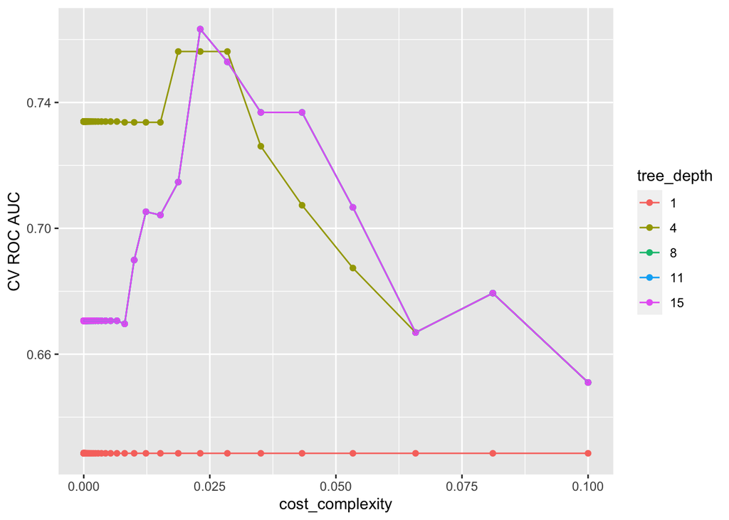

```r
tree_fit %>%
  collect_metrics() %>%
  print(width = Inf) %>%
  filter(.metric == "roc_auc") %>%
  mutate(tree_depth = as.factor(tree_depth)) %>%
  ggplot(mapping = aes(x = cost_complexity, y = mean, color = tree_depth)) +
  geom_point() +
  geom_line() +
  labs(x = "cost_complexity", y = "CV ROC AUC", color = "tree_depth")
```

**Finalize our model:**

```r
tree_fit %>%
  show_best("roc_auc")
```

```
# A tibble: 5 × 8
  cost_complexity tree_depth .metric .estimator  mean     n std_err .config
            <dbl>      <int> <chr>   <chr>      <dbl> <int>   <dbl> <chr>
1          0.0231          8 roc_auc binary     0.763     5  0.0148 Preprocesso…
2          0.0231         11 roc_auc binary     0.763     5  0.0148 Preprocesso…
3          0.0231         15 roc_auc binary     0.763     5  0.0148 Preprocesso…
4          0.0187          4 roc_auc binary     0.756     5  0.0165 Preprocesso…
5          0.0231          4 roc_auc binary     0.756     5  0.0165 Preprocesso…
```

Select the best model.

```r
best_tree <- tree_fit %>%
  select_best("roc_auc")
best_tree
```

```
# A tibble: 1 × 3
  cost_complexity tree_depth .config
            <dbl>      <int> <chr>
1          0.0231          8 Preprocessor1_Model293
```

```r
# Final workflow
final_wf <- tree_wf %>%
  finalize_workflow(best_tree)
final_wf
```

```
══ Workflow ════════════════════════════════════════════════════════════════════
Preprocessor: Recipe
Model: decision_tree()

── Preprocessor ────────────────────────────────────────────────────────────────
4 Recipe Steps

• step_naomit()
• step_dummy()
• step_zv()
• step_normalize()

── Model ───────────────────────────────────────────────────────────────────────
Decision Tree Model Specification (classification)

Main Arguments:
  cost_complexity = 0.0231012970008316
  tree_depth = 8
  min_n = 5

Computational engine: rpart
```

```r
# Fit the whole training set, then predict the test cases
final_fit <-
  final_wf %>%
  last_fit(data_split)
final_fit
```

```
# Resampling results
# Manual resampling
# A tibble: 1 × 6
  splits            id               .metrics .notes   .predictions .workflow
  <list>            <chr>            <list>   <list>   <list>       <list>
1 <split [200/200]> train/test split <tibble> <tibble> <tibble>     <workflow>
```

```r
# Test metrics
final_fit %>%
  collect_metrics()
```

```
# A tibble: 2 × 4
  .metric  .estimator .estimate .config
  <chr>    <chr>          <dbl> <chr>
1 accuracy binary         0.755 Preprocessor1_Model1
2 roc_auc  binary         0.760 Preprocessor1_Model1
```

** Visualize the final model:**

```r
library(rpart.plot)
final_tree <- extract_workflow(final_fit)
final_tree
```

```
══ Workflow [trained] ══════════════════════════════════════════════════════════
Preprocessor: Recipe
Model: decision_tree()

── Preprocessor ────────────────────────────────────────────────────────────────
4 Recipe Steps

• step_naomit()
• step_dummy()
• step_zv()
• step_normalize()

── Model ───────────────────────────────────────────────────────────────────────
n= 200

node), split, n, loss, yval, (yprob)
      * denotes terminal node

 1) root 200 82 Low (0.41000000 0.59000000)
   2) ShelveLoc_Good>=0.6742344 44  9 High (0.79545455 0.20454545)
     4) Price< 1.204802 36  3 High (0.91666667 0.08333333) *
     5) Price>=1.204802 8  2 Low (0.25000000 0.75000000) *
   3) ShelveLoc_Good< 0.6742344 156 47 Low (0.30128205 0.69871795)
     6) Price< -0.9414209 26  8 High (0.69230769 0.30769231)
      12) Income>=0.6401903 12  1 High (0.91666667 0.08333333) *
      13) Income< 0.6401903 14  7 High (0.50000000 0.50000000)
        26) ShelveLoc_Medium>=-0.0499373 9  2 High (0.77777778 0.22222222) *
        27) ShelveLoc_Medium< -0.0499373 5  0 Low (0.00000000 1.00000000) *
     7) Price>=-0.9414209 130 29 Low (0.22307692 0.77692308)
      14) Advertising>=0.78991 26 12 High (0.53846154 0.46153846)
        28) Price< 0.8505711 20  6 High (0.70000000 0.30000000)
          56) CompPrice>=-0.787038 16  2 High (0.87500000 0.12500000) *
          57) CompPrice< -0.787038 4  0 Low (0.00000000 1.00000000) *
        29) Price>=0.8505711 6  0 Low (0.00000000 1.00000000) *
      15) Advertising< 0.78991 104 15 Low (0.14423077 0.85576923)
        30) CompPrice>=1.238547 15  6 Low (0.40000000 0.60000000)
          60) Income>=0.247091 6  1 High (0.83333333 0.16666667) *
          61) Income< 0.247091 9  1 Low (0.11111111 0.88888889) *
        31) CompPrice< 1.238547 89  9 Low (0.10112360 0.89887640) *
```

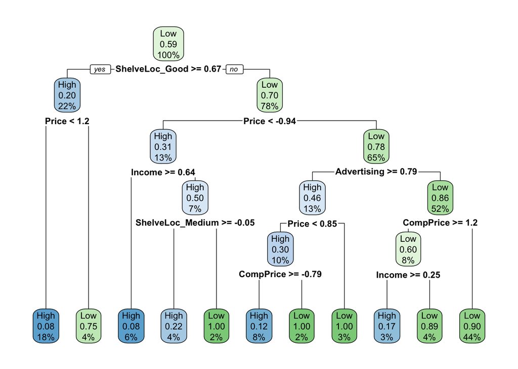

```r
final_tree %>%
  extract_fit_engine() %>%
  rpart.plot(roundint = FALSE)
```

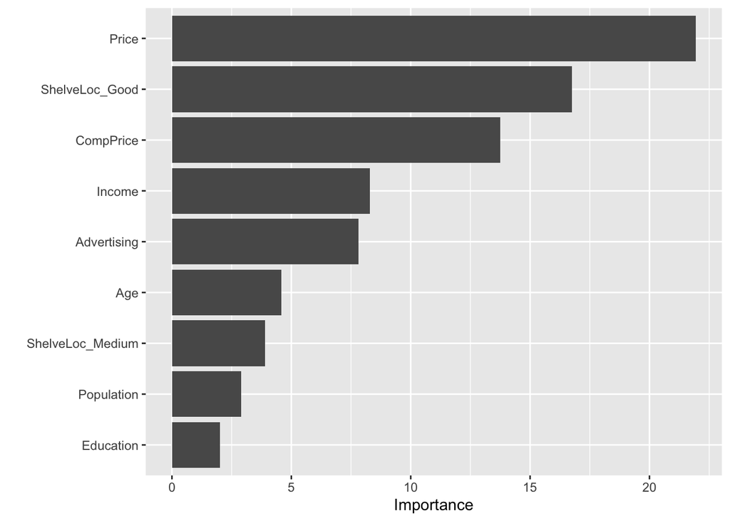

```r
library(vip)

final_tree %>%
  extract_fit_parsnip() %>%
  vip()
```

**random forest:**

**Recipe:**

```r
rf_recipe <-
  recipe(
    Sales ~ .,
    data = Carseats_other
  ) %>%
  # # create traditional dummy variables (not necessary for random forest in R)
  # step_dummy(all_nominal()) %>%
  # mean imputation for Ca
  #step_impute_mean(Ca) %>%
  # mode imputation for Thal
  #step_impute_mode(Thal) %>%
  # zero-variance filter
  step_zv(all_numeric_predictors()) %>%
  # # center and scale numeric data (not necessary for random forest)
  # step_normalize(all_numeric_predictors()) %>%
  # estimate the means and standard deviations
  prep(training = Carseats_other, retain = TRUE)
rf_recipe
```

**Model:**

```r
rf_mod <-
  rand_forest(
    mode = "classification",
    # Number of predictors randomly sampled in each split
    mtry = tune(),
    # Number of trees in ensemble
    trees = tune()
  ) %>%
  set_engine("ranger")
rf_mod
```

```
Random Forest Model Specification (classification)

Main Arguments:
  mtry = tune()
  trees = tune()

Computational engine: ranger
```

**Workflow:**

```r
rf_wf <- workflow() %>%
  add_recipe(rf_recipe) %>%
  add_model(rf_mod)
rf_wf
```

```
══ Workflow ════════════════════════════════════════════════════════════════════
Preprocessor: Recipe
Model: rand_forest()

── Preprocessor ────────────────────────────────────────────────────────────────
1 Recipe Step

• step_zv()

── Model ───────────────────────────────────────────────────────────────────────
Random Forest Model Specification (classification)

Main Arguments:
  mtry = tune()
  trees = tune()

Computational engine: ranger
```

**Tuning grid:**

```r
param_grid <- grid_regular(
  trees(range = c(100L, 300L)),
  mtry(range = c(1L, 5L)),
  levels = c(3, 5)
  )
param_grid
```

```
# A tibble: 15 × 2
   trees  mtry
   <int> <int>
 1   100     1
 2   200     1
 3   300     1
 4   100     2
 5   200     2
 6   300     2
 7   100     3
 8   200     3
 9   300     3
10   100     4
11   200     4
12   300     4
13   100     5
14   200     5
15   300     5
```

**Cross-validation:**

```r
set.seed(203)

folds <- vfold_cv(Carseats_other, v = 5)
folds
```

```
#  5-fold cross-validation
# A tibble: 5 × 2
  splits           id
  <list>           <chr>
1 <split [160/40]> Fold1
2 <split [160/40]> Fold2
3 <split [160/40]> Fold3
4 <split [160/40]> Fold4
5 <split [160/40]> Fold5
```

Fit cross-validation:

```r
rf_fit <- rf_wf %>%
  tune_grid(
    resamples = folds,
    grid = param_grid,
    metrics = metric_set(roc_auc, accuracy)
    )
rf_fit
```

```
# Tuning results
# 5-fold cross-validation
# A tibble: 5 × 4
  splits           id    .metrics          .notes
  <list>           <chr> <list>            <list>
1 <split [160/40]> Fold1 <tibble [30 × 6]> <tibble [0 × 3]>
2 <split [160/40]> Fold2 <tibble [30 × 6]> <tibble [0 × 3]>
3 <split [160/40]> Fold3 <tibble [30 × 6]> <tibble [0 × 3]>
4 <split [160/40]> Fold4 <tibble [30 × 6]> <tibble [0 × 3]>
5 <split [160/40]> Fold5 <tibble [30 × 6]> <tibble [0 × 3]>
```

Visualize CV results:

```
# A tibble: 30 × 8
    mtry trees .metric  .estimator  mean     n std_err .config
   <int> <int> <chr>    <chr>      <dbl> <int>   <dbl> <chr>
 1     1   100 accuracy binary     0.755     5  0.0320 Preprocessor1_Model01
 2     1   100 roc_auc  binary     0.827     5  0.0362 Preprocessor1_Model01
 3     1   200 accuracy binary     0.72      5  0.0184 Preprocessor1_Model02
 4     1   200 roc_auc  binary     0.814     5  0.0310 Preprocessor1_Model02
 5     1   300 accuracy binary     0.715     5  0.0170 Preprocessor1_Model03
 6     1   300 roc_auc  binary     0.807     5  0.0235 Preprocessor1_Model03
 7     2   100 accuracy binary     0.745     5  0.0146 Preprocessor1_Model04
 8     2   100 roc_auc  binary     0.834     5  0.0274 Preprocessor1_Model04
 9     2   200 accuracy binary     0.735     5  0.0170 Preprocessor1_Model05
10     2   200 roc_auc  binary     0.832     5  0.0259 Preprocessor1_Model05
# ℹ 20 more rows
```

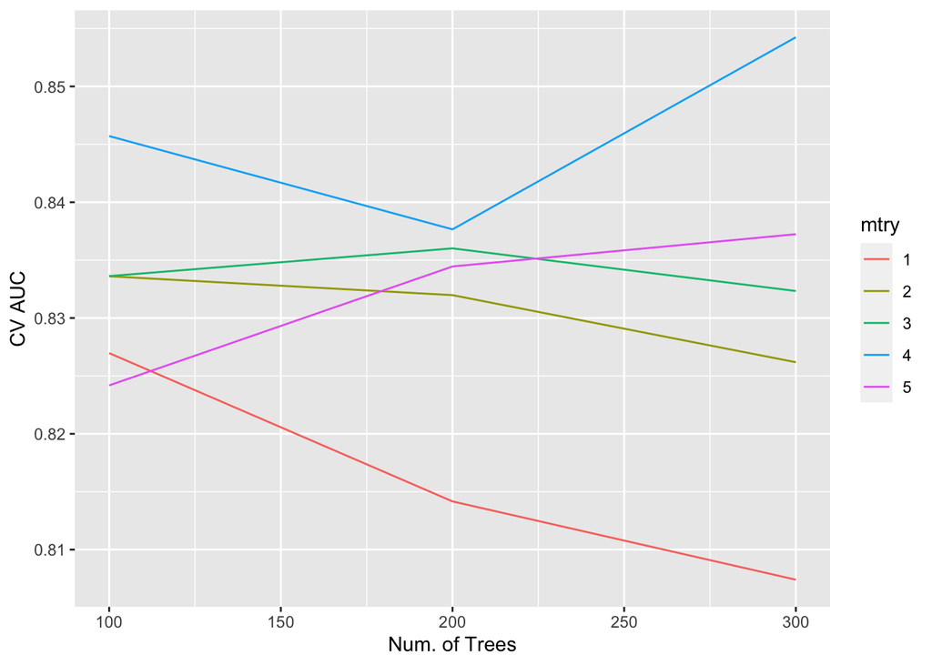

```r
rf_fit %>%
  collect_metrics() %>%
  print(width = Inf) %>%
  filter(.metric == "roc_auc") %>%
  mutate(mtry = as.factor(mtry)) %>%
  ggplot(mapping = aes(x = trees, y = mean, color = mtry)) +
  # geom_point() +
  geom_line() +
  labs(x = "Num. of Trees", y = "CV AUC")
```

Show the top 5 models:

```r
rf_fit %>%
  show_best("roc_auc")
```

```
# A tibble: 5 × 8
   mtry trees .metric .estimator  mean     n std_err .config
  <int> <int> <chr>   <chr>      <dbl> <int>   <dbl> <chr>
1     4   300 roc_auc binary     0.854     5  0.0263 Preprocessor1_Model12
2     4   100 roc_auc binary     0.846     5  0.0239 Preprocessor1_Model10
3     4   200 roc_auc binary     0.838     5  0.0299 Preprocessor1_Model11
4     5   300 roc_auc binary     0.837     5  0.0281 Preprocessor1_Model15
5     3   200 roc_auc binary     0.836     5  0.0301 Preprocessor1_Model08
```

Select the best model:

```r
best_rf <- rf_fit %>%
  select_best("roc_auc")
best_rf
```

```
# A tibble: 1 × 3
   mtry trees .config
  <int> <int> <chr>
1     4   300 Preprocessor1_Model12
```

**Finalize our model:**

```r
# Final workflow
final_wf <- rf_wf %>%
  finalize_workflow(best_rf)
final_wf
```

```
══ Workflow ════════════════════════════════════════════════════════════════════
Preprocessor: Recipe
Model: rand_forest()

── Preprocessor ────────────────────────────────────────────────────────────────
1 Recipe Step

• step_zv()

── Model ───────────────────────────────────────────────────────────────────────
Random Forest Model Specification (classification)

Main Arguments:
  mtry = 4
  trees = 300

Computational engine: ranger
```

```r
# Fit the whole training set, then predict the test cases
final_fit <-
  final_wf %>%
  last_fit(data_split)
final_fit
```

```
# Resampling results
# Manual resampling
# A tibble: 1 × 6
  splits            id               .metrics .notes   .predictions .workflow
  <list>            <chr>            <list>   <list>   <list>       <list>
1 <split [200/200]> train/test split <tibble> <tibble> <tibble>     <workflow>
```

```r
# Test metrics
final_fit %>%
  collect_metrics()
```

```
# A tibble: 2 × 4
  .metric  .estimator .estimate .config
  <chr>    <chr>          <dbl> <chr>
1 accuracy binary         0.78  Preprocessor1_Model1
2 roc_auc  binary         0.874 Preprocessor1_Model1
```

**boosting methods**

**Recipe:**

```r
gb_recipe <-
  recipe(
    Sales ~ .,
    data = Carseats_other
  ) %>%
  # mean imputation for Ca
  #step_impute_mean(Ca) %>%
  # mode imputation for Thal
  #step_impute_mode(Thal) %>%
  # create traditional dummy variables (necessary for xgboost)
  step_dummy(all_nominal_predictors()) %>%
  # zero-variance filter
  step_zv(all_numeric_predictors()) %>%
  # estimate the means and standard deviations
  prep(training = Carseats_other, retain = TRUE)
gb_recipe
```

**Model:**

```r
gb_mod <-
  boost_tree(
    mode = "classification",
    trees = 1000,
    tree_depth = tune(),
    learn_rate = tune()
  ) %>%
  set_engine("xgboost")
gb_mod
```

```
Boosted Tree Model Specification (classification)

Main Arguments:
  trees = 1000
  tree_depth = tune()
  learn_rate = tune()

Computational engine: xgboost
```

**Workflow:**

```r
gb_wf <- workflow() %>%
  add_recipe(gb_recipe) %>%
  add_model(gb_mod)
gb_wf
```

```
══ Workflow ════════════════════════════════════════════════════════════════════
Preprocessor: Recipe
Model: boost_tree()

── Preprocessor ────────────────────────────────────────────────────────────────
2 Recipe Steps

• step_dummy()
• step_zv()

── Model ───────────────────────────────────────────────────────────────────────
Boosted Tree Model Specification (classification)

Main Arguments:
  trees = 1000
  tree_depth = tune()
  learn_rate = tune()

Computational engine: xgboost
```

**Tuning grid:**

```r
param_grid <- grid_regular(
  tree_depth(range = c(1L, 3L)),
  learn_rate(range = c(-5, 2), trans = log10_trans()),
  levels = c(3, 10)
  )
param_grid
```

```
# A tibble: 30 × 2
   tree_depth learn_rate
        <int>      <dbl>
 1          1  0.00001
 2          2  0.00001
 3          3  0.00001
 4          1  0.0000599
 5          2  0.0000599
 6          3  0.0000599
 7          1  0.000359
 8          2  0.000359
 9          3  0.000359
10          1  0.00215
# ℹ 20 more rows
```

**Cross-validation:**

```r
set.seed(203)

folds <- vfold_cv(Carseats_other, v = 5)
folds
```

```
#  5-fold cross-validation
# A tibble: 5 × 2
  splits           id
  <list>           <chr>
1 <split [160/40]> Fold1
2 <split [160/40]> Fold2
3 <split [160/40]> Fold3
4 <split [160/40]> Fold4
5 <split [160/40]> Fold5
```

Fit cross-validation:

```r
gb_fit <- gb_wf %>%
  tune_grid(
    resamples = folds,
    grid = param_grid,
    metrics = metric_set(roc_auc, accuracy)
    )
gb_fit
```

```
# Tuning results
# 5-fold cross-validation
# A tibble: 5 × 4
  splits           id    .metrics          .notes
  <list>           <chr> <list>            <list>
1 <split [160/40]> Fold1 <tibble [60 × 6]> <tibble [0 × 3]>
2 <split [160/40]> Fold2 <tibble [60 × 6]> <tibble [0 × 3]>
3 <split [160/40]> Fold3 <tibble [60 × 6]> <tibble [0 × 3]>
4 <split [160/40]> Fold4 <tibble [60 × 6]> <tibble [0 × 3]>
5 <split [160/40]> Fold5 <tibble [60 × 6]> <tibble [0 × 3]>
```

Visualize CV results:

```
# A tibble: 60 × 8
   tree_depth learn_rate .metric  .estimator  mean     n std_err
        <int>      <dbl> <chr>    <chr>      <dbl> <int>   <dbl>
 1          1  0.00001   accuracy binary     0.69      5  0.0430
 2          1  0.00001   roc_auc  binary     0.661     5  0.0502
 3          2  0.00001   accuracy binary     0.735     5  0.0376
 4          2  0.00001   roc_auc  binary     0.722     5  0.0376
 5          3  0.00001   accuracy binary     0.755     5  0.045
 6          3  0.00001   roc_auc  binary     0.764     5  0.0581
 7          1  0.0000599 accuracy binary     0.68      5  0.0391
 8          1  0.0000599 roc_auc  binary     0.684     5  0.0381
 9          2  0.0000599 accuracy binary     0.735     5  0.0376
10          2  0.0000599 roc_auc  binary     0.760     5  0.0519
   .config
   <chr>
 1 Preprocessor1_Model01
 2 Preprocessor1_Model01
 3 Preprocessor1_Model02
 4 Preprocessor1_Model02
 5 Preprocessor1_Model03
 6 Preprocessor1_Model03
 7 Preprocessor1_Model04
 8 Preprocessor1_Model04
 9 Preprocessor1_Model05
10 Preprocessor1_Model05
# ℹ 50 more rows
```

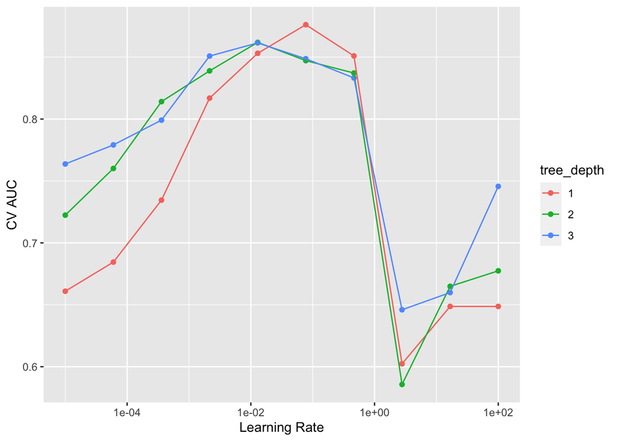

```r
gb_fit %>%
  collect_metrics() %>%
  print(width = Inf) %>%
  filter(.metric == "roc_auc") %>%
  mutate(tree_depth = as.factor(tree_depth)) %>%
  ggplot(mapping = aes(x = learn_rate, y = mean, color = tree_depth)) +
  geom_point() +
  geom_line() +
  labs(x = "Learning Rate", y = "CV AUC") +
  scale_x_log10()
```

Show the top 5 models.

```r
gb_fit %>%
  show_best("roc_auc")
```

```
# A tibble: 5 × 8
  tree_depth learn_rate .metric .estimator  mean     n std_err .config
       <int>      <dbl> <chr>   <chr>      <dbl> <int>   <dbl> <chr>
1          1     0.0774 roc_auc binary     0.876     5  0.0513 Preprocessor1_Mo…
2          2     0.0129 roc_auc binary     0.862     5  0.0483 Preprocessor1_Mo…
3          3     0.0129 roc_auc binary     0.862     5  0.0495 Preprocessor1_Mo…
4          1     0.0129 roc_auc binary     0.853     5  0.0401 Preprocessor1_Mo…
5          1     0.464  roc_auc binary     0.851     5  0.0499 Preprocessor1_Mo…
```

Select the best model.

```r
best_gb <- gb_fit %>%
  select_best("roc_auc")
best_gb
```

```
# A tibble: 1 × 3
  tree_depth learn_rate .config
       <int>      <dbl> <chr>
1          1     0.0774 Preprocessor1_Model16
```

**Finalize our model:**

```r
# Final workflow
final_wf <- gb_wf %>%
  finalize_workflow(best_gb)
final_wf
```

```
══ Workflow ════════════════════════════════════════════════════════════════════
Preprocessor: Recipe
Model: boost_tree()

── Preprocessor ────────────────────────────────────────────────────────────────
2 Recipe Steps

• step_dummy()
• step_zv()

── Model ───────────────────────────────────────────────────────────────────────
Boosted Tree Model Specification (classification)

Main Arguments:
  trees = 1000
  tree_depth = 1
  learn_rate = 0.0774263682681127

Computational engine: xgboost
```

```r
# Fit the whole training set, then predict the test cases
final_fit <-
  final_wf %>%
  last_fit(data_split)
final_fit
```

```
# Resampling results
# Manual resampling
# A tibble: 1 × 6
  splits            id               .metrics .notes   .predictions .workflow
  <list>            <chr>            <list>   <list>   <list>       <list>
1 <split [200/200]> train/test split <tibble> <tibble> <tibble>     <workflow>
```

```r
# Test metrics
final_fit %>%
  collect_metrics()
```

```
# A tibble: 2 × 4
  .metric  .estimator .estimate .config
  <chr>    <chr>          <dbl> <chr>
1 accuracy binary         0.845 Preprocessor1_Model1
2 roc_auc  binary         0.918 Preprocessor1_Model1
```